# Greenhouse Gas Emissions

Anuja Janet, Srinivasa Keerthy Vishnubhotla, Molly Witzenburg

December 5, 2017

# Data Cleaning:

# 1. Description of Data Source

- Our primary data is a table from the Organisation for Economic Cooperation and Development (OECD). The table consists of 24,948 rows and 8 columns. The columns include Country, the type of pollutant being measured (Subject), the scale of measurement (Measure), the value of the measurement (Value), and the year it was taken (Time). It also includes undefined Flag Codes, Indicator, and Frequency columns.

**Citation:** OECD (2017), Air and GHG emissions (indicator). doi: 10.1787/93d10cf7-en URL: https://data.oecd.org/air/air-and-ghg-emissions.htm (Accessed on 10 October 2017)

**Citation:** The World Bank: Urban Population (% of Total): The United Nations Population Divisions World Urbanization Prospects. URL: https://data.worldbank.org/indicator/SP.URB.TOTL.IN.ZS (Accessed on 10 October 2017)

**Citation:** The World Bank: Urban Population (% of Total): The United Nations Population Divisions World Urbanization Prospects. URL: https://data.worldbank.org/indicator/SP.POP.TOTL?page=2 (Accessed on 11 October 2017)

# 2. Intellectual Property Constraints

- **OECD Data:** In consideration of the Subscription Fee, and the agreement to abide by these Terms and Conditions, the OECD grants the Customer a non-exclusive and non-transferable right to access and display on its secure internal network, for use by Authorised Users only, the online service “OECD iLibrary” (http://www.oecd-ilibrary.org) and the title (or titles) and content contained therein which has (or have) been subscribed to including the back catalogue of PDFs where available (hereinafter referred to as the “Work”). The Work may be accessed by End Users either directly from the OECD itself, or from a designated Third Party (e.g. Publishing Technology) either on the Customer’s premises or from a remote location. Irrespective of the method of access, the conditions of use, as described in these Terms and Conditions, remain in force. The OECD affirms that it holds all rights granted herein, and reserves all those not expressly granted to the Customer.  
  “Authorised Users” are defined as being;
1. For Academic and Not-For-Profit Organisations - those members of faculty or staff, either permanent, temporary, contract, visiting or retired, or students, or alumni or other persons permitted to use the institution’s library services.
- **World Bank Data:** Open License

# 3. Description of Metadata

- **OECD Data:** No official metadata is available for the data. There is an interactive tool on the website allowing the user to look up what country each three-letter code represents, and what environmental toxins are represented by each abbreviation.
- **World Bank Data:** Metadata can be found here: http://databank.worldbank.org/data/reports.aspx?source=2&type=metadata&series=SP.POP.TOTL

# 4. Data Issues

**A. OECD Data:**

**Missing values**

- Flag code column has missing values.
- Missing values in Value column.

**Undefined Variables**

- Column ‘Flag Code’ has undefined entries ‘L’ and ‘B’ (perhaps Lost and Blank or Broken?). Flag codes, in order of frequency from least to greatest are B (30), L (3693), and blank (21225). Flag codes of B do not apply to any GHG (Greenhouse Gases) or CO2 (Carbon Dioxide) records, and do contain Values. Flag Codes of B come from Poland (1995), Turkey, USA, and Mexico (the latter three all from 2005 and 2008). All Flag Codes of L correspond to C02 readings and all Values are blank for these records.
- Column ‘Frequency’ has uniform entries of ‘A’ which is undefined.
- Column ‘Indicator’ has uniform entries of ‘AirEmission’ which is undefined.

**B. World Bank Data:**

**Missing values:**

- There is no Urbanization data nor Population data for Taiwan (aka Chinese Taipei).
- There is no Urbanization data nor Population data for Eritrea from 2011 through 2014.
- There is no Population data for Kuwait from 1992 through 1994.

# 5. Rationale for Data Remediation

We are interested in comparing individual country greenhouse gas emissions to one another and to world totals and OECD member country totals. We felt that the other summaries of data (EU28 being 28 member nations of the EU, G20 nations, OEU and OECDE both being the European members of OECD) should be eliminated since they were summarized data.

Flag codes were not explained but we observed that any flag code of L corresponded to CO2 records with no value. These were the only records that contained no value. We did not feel we had adequate information to make any assumptions about the missing values so we eliminated those records.

One of our questions requires us to use data about population and urbanization rates so we appended that information to our data.

# 6. Script or Description of Data Cleaning Process

## **Step 2:**

### Merge Urbanization and Emissions data

- Create a new tab called “Urbanization” in air_ghg_emissions data file and paste in Urbanization data from World Bank
- Create an index column in main project data page to use in vlookup:  
  `=IF(F3=1960,4,F3-1960+4)` and copy to every row.
- Where F3 is the TIME column.
- Do vlookup for urbanization data:  
  `=VLOOKUP(A3,Urbanization!$B$2:$BI$265,I3)`
- Where A3 is the three letter country code column,
- Country name column is not included in the LookUp table (note the range begins with column B),  
  and I3 is the index created in the previous step.
- Copy the formula to each row of the data.

## **Step 3:**

### Merge Population.csv and air_ghg_emissions.csv data

- Create a new tab called “Population” in air_ghg_emissions data file and paste in Population data from World Bank
- Do vlookup for population data in the main project data page:  
  `=VLOOKUP(A3,Population!$B$2:$BI$265,I3)`
- Where A3 is the three letter country code column,
- Country name column is not included in the LookUp table (note the range begins with column B), and
- I3 is the index created in the Urbanization merge (urbanization and population are from the same source and formatted in the same manner).
- Copy the formula to each row of the data.
- Save file as air_ghg_data_with_formulas_1130.xlsx

## **Step 4:**

### Create final csv file

- Copy the new expanded table, and paste as values into a new file. Save as air_ghg_data_w_regions_new1130.csv.

# R Script for Analysis:

# Q1:

## Which countries and regions contribute the most CO2 emissions, both on a total volume basis and from a per capita perspective? Do the top offenders have similar patterns of increasing and decreasing emissions?

### Read the csv file:

```r
ghg <- read.csv("https://raw.githubusercontent.com/MBWitz/DataSurfers/master/air_ghg_data_w_regions_new1130.csv")
```

### View a summary of the data:

```r
summary(ghg)
```

```
##     COUNTRY            INDICATOR     SUBJECT              MEASURE
##  AUS    :  362   AIREMISSION:20726   CO : 1764   KG_CAP       :3527
##  AUT    :  362                       CO2:11650   MLN_TONNE    :5825
##  BEL    :  362                       GHG: 2022   THND_TONNE   :3527
##  CAN    :  362                       NOX: 1764   THND_TONNECO2:1011
##  CHE    :  362                       SOX: 1764   TONNE_CAP    :6836
##  DEU    :  362                       VOC: 1762
##  (Other):18554
##  FREQUENCY      TIME          Value          Flag.Codes
##  A:20726   Min.   :1960   Min.   :       0    :20696
##            1st Qu.:1990   1st Qu.:       5   B:   30
##            Median :1998   Median :      20
##            Mean   :1997   Mean   :   45565
##            3rd Qu.:2007   3rd Qu.:     126
##            Max.   :2015   Max.   :16844806
##
##  Lookup.Column.Index Urbanization.       Population
##  Min.   : 4.00       Min.   :  4.005   Min.   :1.194e+05
##  1st Qu.:34.00       1st Qu.: 53.360   1st Qu.:4.491e+06
##  Median :42.00       Median : 68.862   Median :1.030e+07
##  Mean   :40.62       Mean   : 65.030   Mean   :7.998e+07
##  3rd Qu.:51.00       3rd Qu.: 79.583   3rd Qu.:4.000e+07
##  Max.   :59.00       Max.   :100.000   Max.   :7.269e+09
##
##              Region        OECD_Flag
##  Europe         :10022   Min.   :0.000
##  Africa         : 2308   1st Qu.:0.000
##  Western Asia   : 2124   Median :0.000
##  Southern Asia  : 1200   Mean   :0.492
##  Central America: 1130   3rd Qu.:1.000
##  South America  : 1054   Max.   :1.000
##  (Other)        : 2888
```

Summary shows that we do not have enough ghg data points to do meaningful analysis. We have far more data for CO2 emissions, so we will do the same analysis we planned but on CO2 emissions, which are the leading contributor to green house gases.

### Create a subset of just CO2 values:

```r
ghg.sub <- ghg[ghg$SUBJECT == 'CO2', ]
```

### Create a subset of CO2 set with CO2 that is measured in Millions of Tons:

```r
ghg.sub2 <- ghg.sub[ghg.sub$MEASURE == 'MLN_TONNE', ]
```

### Calculate Per Capita CO2 Emissions and include in ghg.sub2:

```r
ghg.sub2$CO2percap <- with(ghg.sub2, (ghg.sub2$Value/ghg.sub2$Population)*1000000)
```

### Create subsets of millions of tons CO2 emissions by year for 2014:

```r
ghg.sub2014 <- ghg.sub2[ghg.sub2$TIME == 2014, ]
```

### Rank the top 20 CO2 producers from 2014, omit top two (World and OED), store in top2014 dataframe:

```r
top2014 <- tail(head(ghg.sub2014[order(ghg.sub2014$Value, decreasing= T),], n = 22), n=20)
```

### Create a barchart of top 20 CO2 producing nation for 2014:

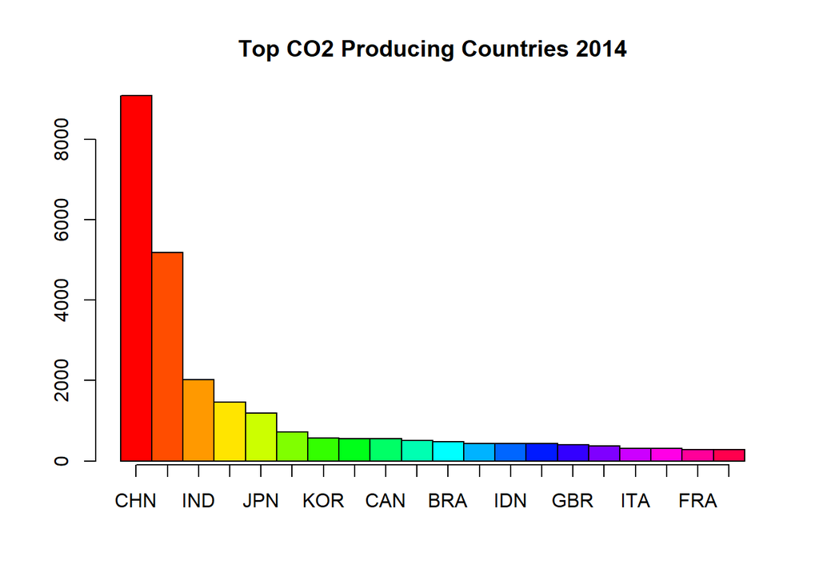

```r
barplot(top2014$Value, main="Top CO2 Producing Countries 2014", col = rainbow(20), space=0)
axis(1, at=.5:19.5, labels=top2014$COUNTRY)
```

### Rank and plot top 20 CO2 producers for 2010:

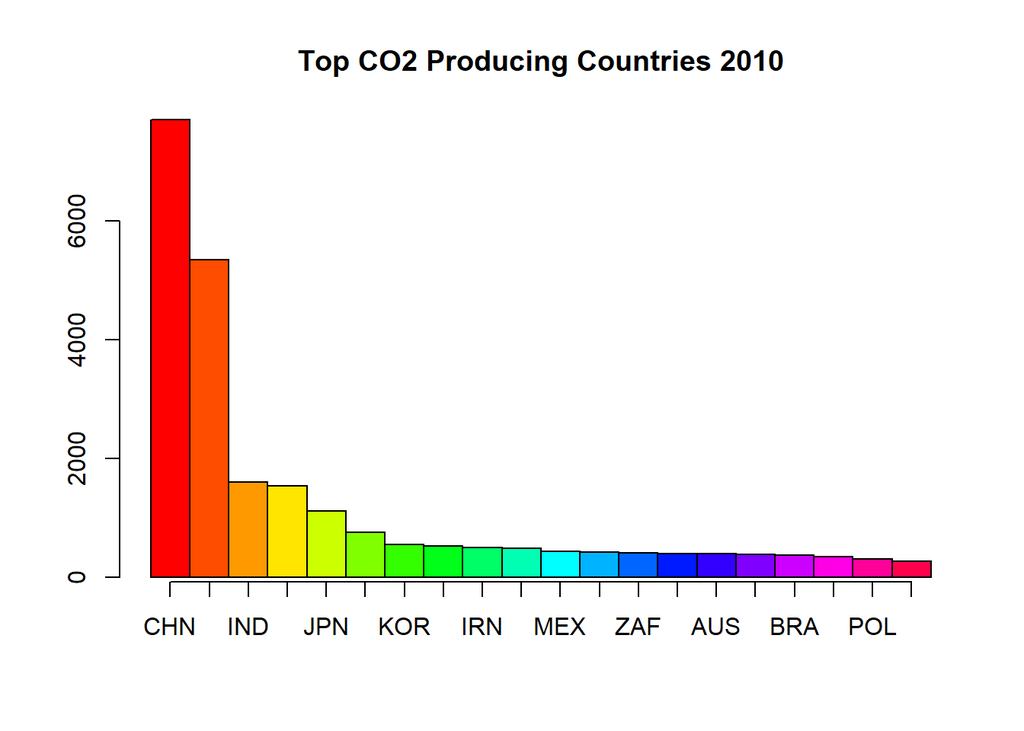

```r
ghg.sub2010<-ghg.sub2[ghg.sub2$TIME == 2010, ]
top2010<-tail(head(ghg.sub2010[order(ghg.sub2010$Value, decreasing= T),], n = 22), n=20)
barplot(top2010$Value, main="Top CO2 Producing Countries 2010", col = rainbow(20), space = 0)
axis(1, at=.5:19.5, labels=top2010$COUNTRY)
```

### Rank and plot top 20 CO2 producers for 2005:

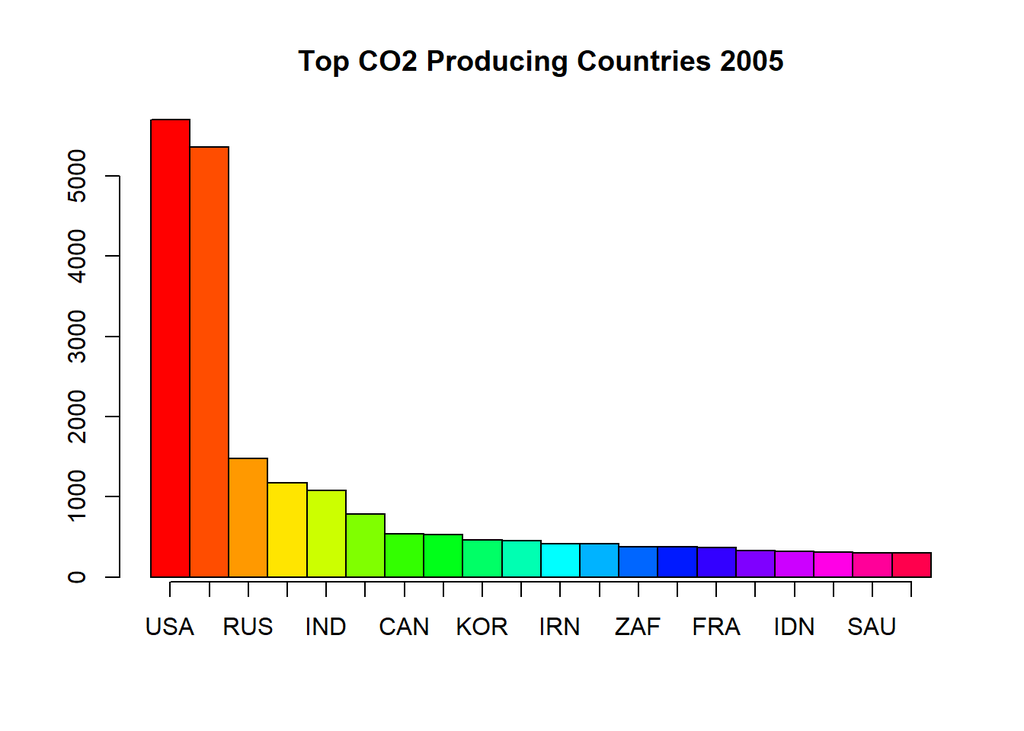

```r
ghg.sub2005<-ghg.sub2[ghg.sub2$TIME == 2005, ]
top2005<-tail(head(ghg.sub2005[order(ghg.sub2005$Value, decreasing= T),], n = 22), n=20)
barplot(top2005$Value, main="Top CO2 Producing Countries 2005", col = rainbow(20), space = 0)
axis(1, at=.5:19.5, labels=top2005$COUNTRY)
```

### Rank and plot top 20 CO2 producers for 2000:

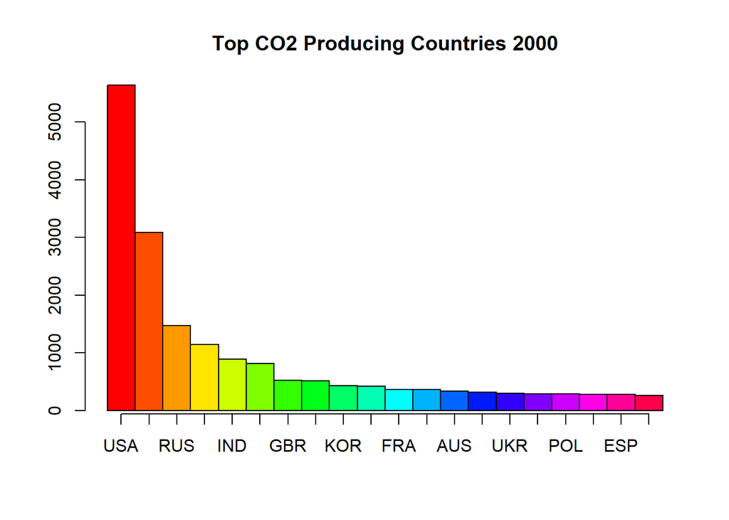

```r
ghg.sub2000<-ghg.sub2[ghg.sub2$TIME == 2000, ]
top2000<-tail(head(ghg.sub2000[order(ghg.sub2000$Value, decreasing= T),], n = 22), n=20)
barplot(top2000$Value, main="Top CO2 Producing Countries 2000", col = rainbow(20), space = 0)
axis(1, at=.5:19.5, labels=top2000$COUNTRY)
```

```r
### Rank and plot top 20 CO2 producers for 1995:
```

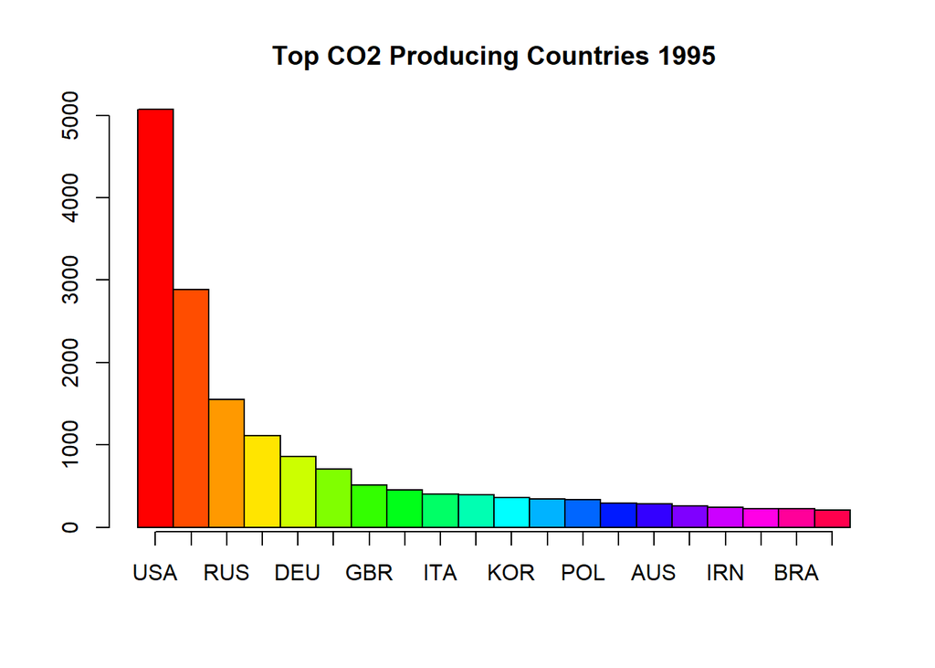

```r
ghg.sub1995<-ghg.sub2[ghg.sub2$TIME == 1995, ]
top1995<-tail(head(ghg.sub1995[order(ghg.sub1995$Value, decreasing= T),], n = 22), n=20)
barplot(top1995$Value, main="Top CO2 Producing Countries 1995", col = rainbow(20), space = 0)
axis(1, at=.5:19.5, labels=top1995$COUNTRY)
```

### Rank and plot top 20 CO2 producers for 1990:

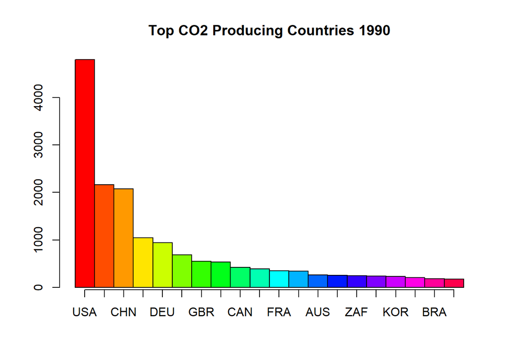

```r
ghg.sub1990<-ghg.sub2[ghg.sub2$TIME == 1990, ]
top1990<-tail(head(ghg.sub1990[order(ghg.sub1990$Value, decreasing= T),], n = 22), n=20)
barplot(top1990$Value, main="Top CO2 Producing Countries 1990", col = rainbow(20), space = 0)
axis(1, at=.5:19.5, labels=top1990$COUNTRY)
```

### Rank and plot top 20 CO2 producers for 1985:

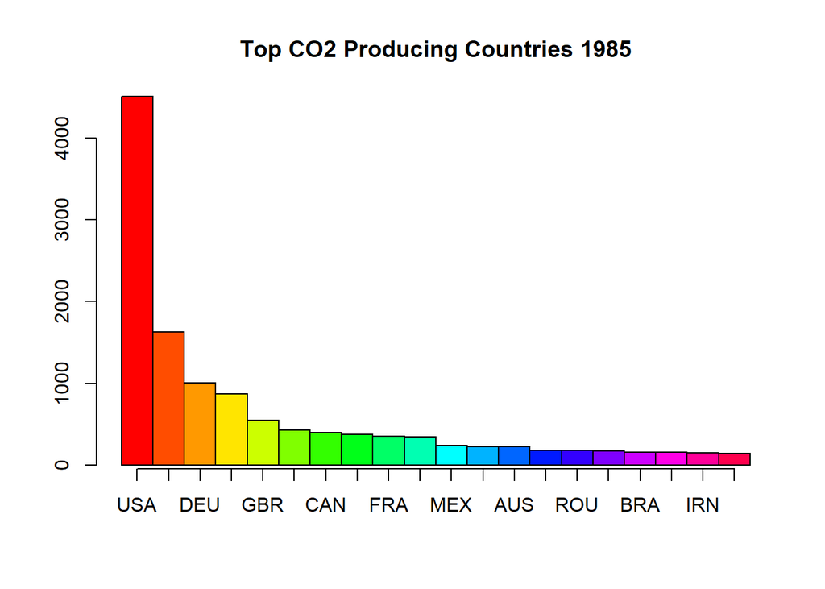

```r
ghg.sub1985<-ghg.sub2[ghg.sub2$TIME == 1985, ]
top1985<-tail(head(ghg.sub1985[order(ghg.sub1985$Value, decreasing= T),], n = 22), n=20)
barplot(top1985$Value, main="Top CO2 Producing Countries 1985", col = rainbow(20), space = 0)
axis(1, at=.5:19.5, labels=top1985$COUNTRY)
```

### Rank and plot top 20 CO2 producers for 1980:

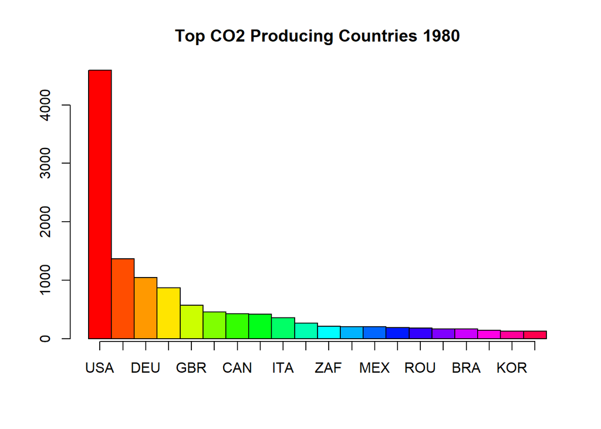

```r
ghg.sub1980<-ghg.sub2[ghg.sub2$TIME == 1980, ]
top1980<-tail(head(ghg.sub1980[order(ghg.sub1980$Value, decreasing= T),], n = 22), n=20)
barplot(top1980$Value, main="Top CO2 Producing Countries 1980", col = rainbow(20), space = 0)
axis(1, at=.5:19.5, labels=top1980$COUNTRY)
```

### Rank and plot top 20 CO2 producers for 1975:

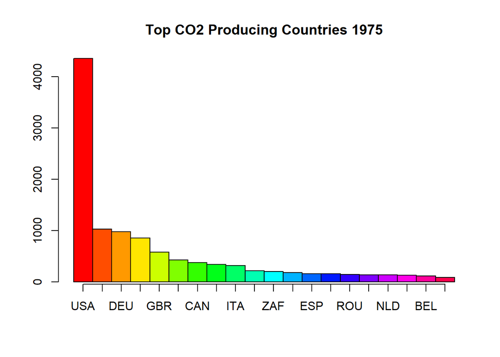

```r
ghg.sub1975<-ghg.sub2[ghg.sub2$TIME == 1975, ]
top1975<-tail(head(ghg.sub1975[order(ghg.sub1975$Value, decreasing= T),], n = 22), n=20)
barplot(top1975$Value, main="Top CO2 Producing Countries 1975", col = rainbow(20), space = 0)
axis(1, at=.5:19.5, labels=top1975$COUNTRY)
```

### Rank and plot top 20 CO2 producers for 1971:

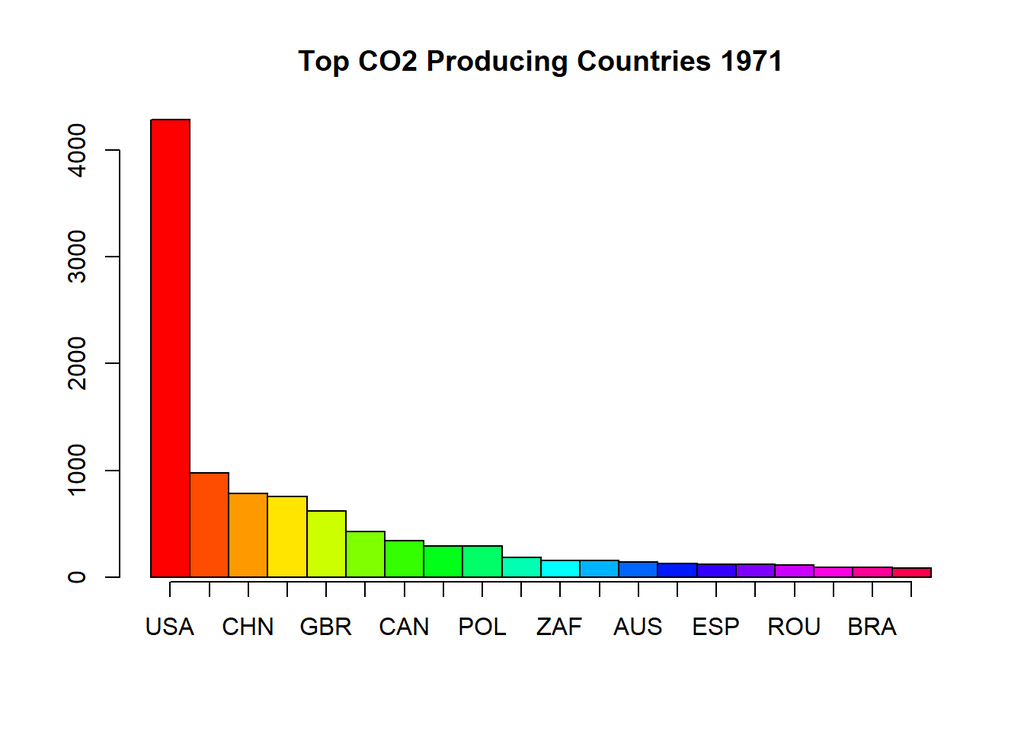

```r
ghg.sub1971<-ghg.sub2[ghg.sub2$TIME == 1971, ]
top1971<-tail(head(ghg.sub1971[order(ghg.sub1971$Value, decreasing= T),], n = 22), n=20)
barplot(top1971$Value, main="Top CO2 Producing Countries 1971", col = rainbow(20), space = 0)
axis(1, at=.5:19.5, labels=top1971$COUNTRY)
```

### Rank the top 50 CO2 Per Capita producers from 2014, store in top2014PC dataframe:

```r
top2014PC <-head(ghg.sub2014[order(ghg.sub2014$CO2percap, decreasing= T),], n = 50)
```

We observed that the top countries for per capita use were not the same as the top countries for volume of CO2 emissions. We had planned on focusing our analysis on the countries with the highest volumes but since many small countries with relatively low volumes actually have high per capita consumption, we want to include their numbers in the analysis. We will therfore do some analysis based on geographic region.

We had to find a list of countries by region, consolidate the regions, then append that information to our data file.

### Aggregate 2014 CO2 Emissions and Population by Region:

```r
Region2014 <- with(ghg.sub2014, (aggregate(list(Population=ghg.sub2014$Population,Value=ghg.sub2014$Value),
                                           by=list(Region=ghg.sub2014$Region), FUN=sum)))
```

### Calculate 2014 CO2 Emissions Per Capita by Region:

```r
Region2014$CO2percap <- with(Region2014, (Region2014$Value/Region2014$Population)*1000000)
Region2014<-Region2014[order(Region2014$CO2percap, decreasing= T),]
```

### Create subsets of millions of tons CO2 emissions for just the USA:

```r
ghg.subUSA <-ghg.sub2[ghg.sub2$COUNTRY == 'USA', ]
```

### plot the USA CO2 emissions over time with year as labels on x-axis :

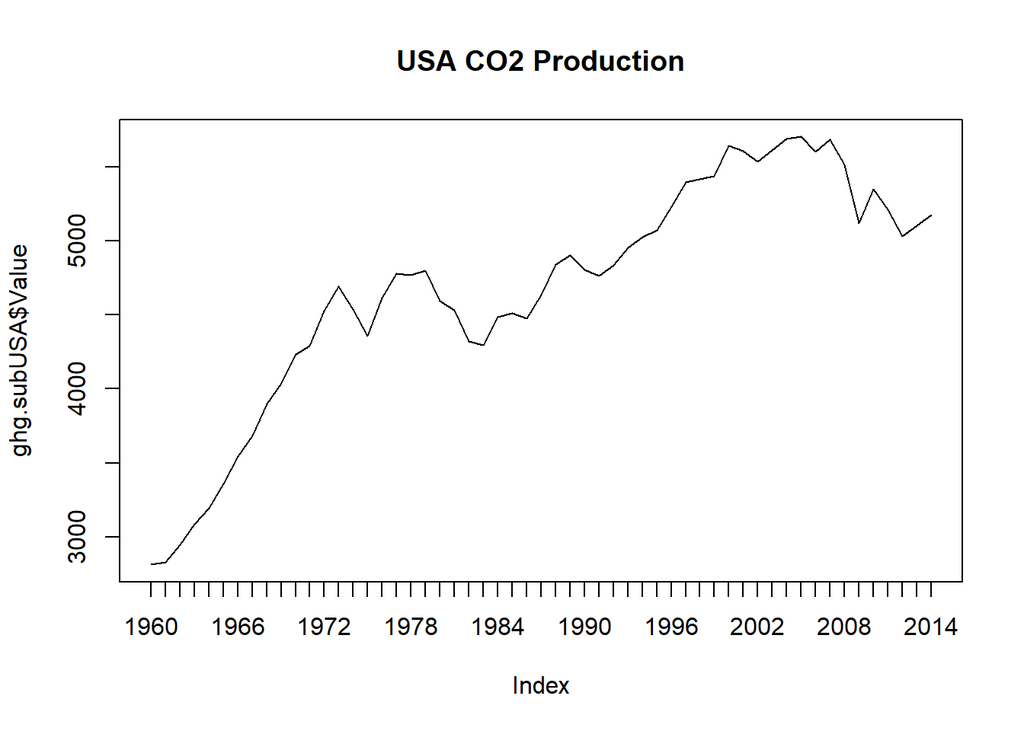

```r
plot(ghg.subUSA$Value,  main="USA CO2 Production", type = "l",  xaxt = "n")
axis(1, at=1:55, labels=ghg.subUSA$TIME)
```

### Create a subset for China and plot their emissions over time:

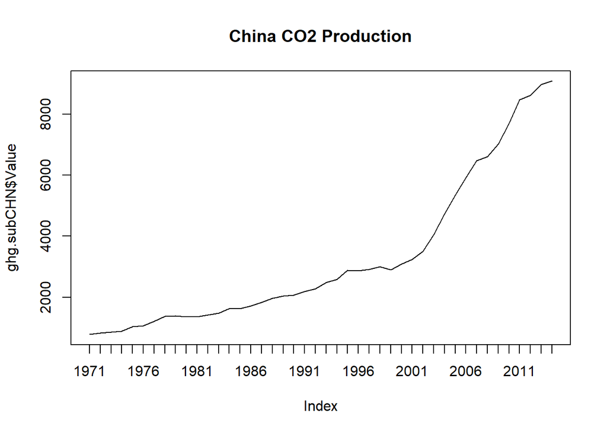

```r
ghg.subCHN <-ghg.sub2[ghg.sub2$COUNTRY == 'CHN', ]
plot(ghg.subCHN$Value,  main="China CO2 Production", type = "l",  xaxt = "n")
axis(1, at=1:44, labels=ghg.subCHN$TIME)
```

*Note that Chinese CO2 production drastically increased in the early 2000’s*

### Create a subset for India and plot their emissions over time:

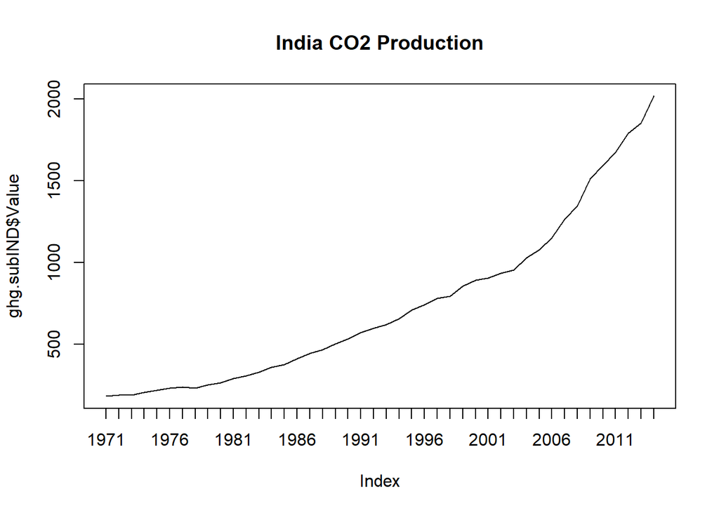

```r
ghg.subIND <-ghg.sub2[ghg.sub2$COUNTRY == 'IND', ]
plot(ghg.subIND$Value,  main="India CO2 Production", type = "l",  xaxt = "n")
axis(1, at=1:44, labels=ghg.subIND$TIME)
```

### Create a subset for Russia and plot their emissions over time:

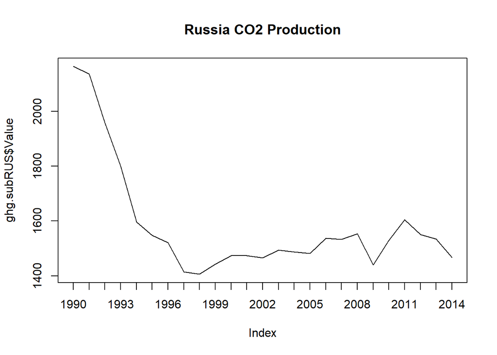

```r
ghg.subRUS <-ghg.sub2[ghg.sub2$COUNTRY == 'RUS', ]
plot(ghg.subRUS$Value,  main="Russia CO2 Production", type = "l",  xaxt = "n")
axis(1, at=1:25, labels=ghg.subRUS$TIME)
```

### Create a subset for Germany and plot their emissions over time:

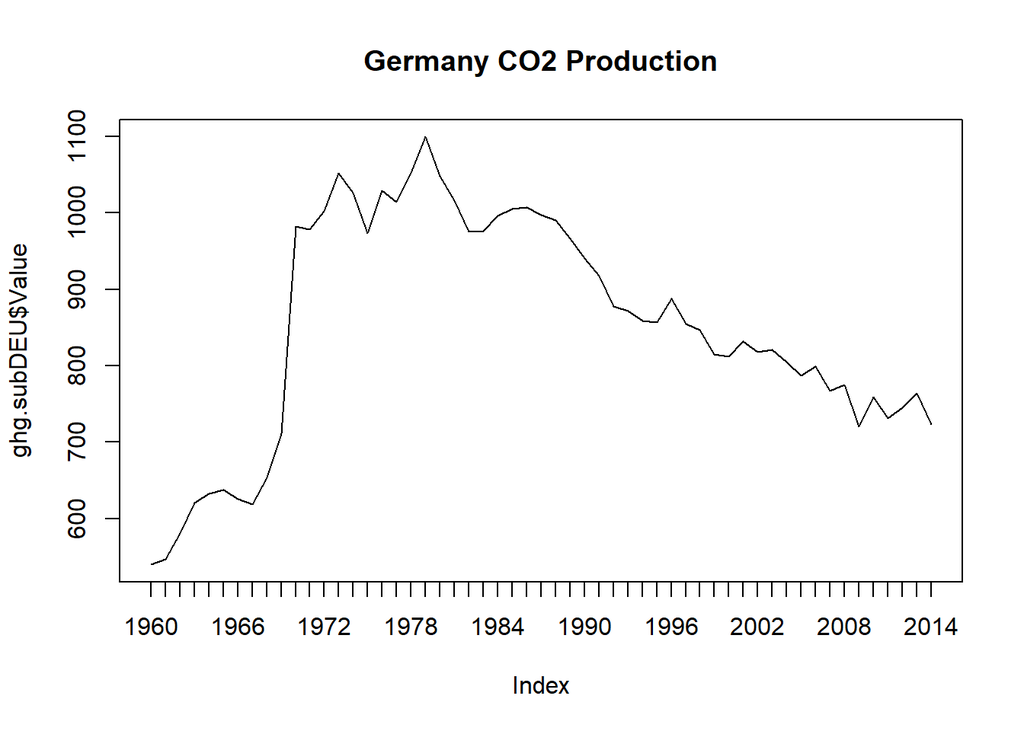

```r
ghg.subDEU <-ghg.sub2[ghg.sub2$COUNTRY == 'DEU', ]
plot(ghg.subDEU$Value,  main="Germany CO2 Production", type = "l",  xaxt = "n")
axis(1, at=1:55, labels=ghg.subDEU$TIME)
```

### Create a subset for Japan and plot their emissions over time:

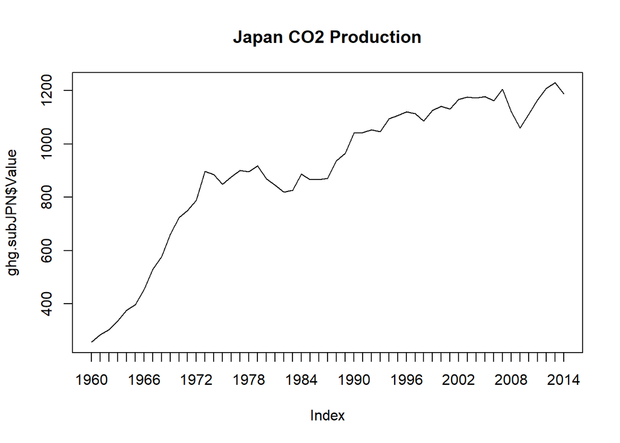

```r
ghg.subJPN <-ghg.sub2[ghg.sub2$COUNTRY == 'JPN', ]
plot(ghg.subJPN$Value,  main="Japan CO2 Production", type = "l",  xaxt = "n")
axis(1, at=1:55, labels=ghg.subJPN$TIME)
```

### Create a subset for United Kingdom and plot their emissions over time:

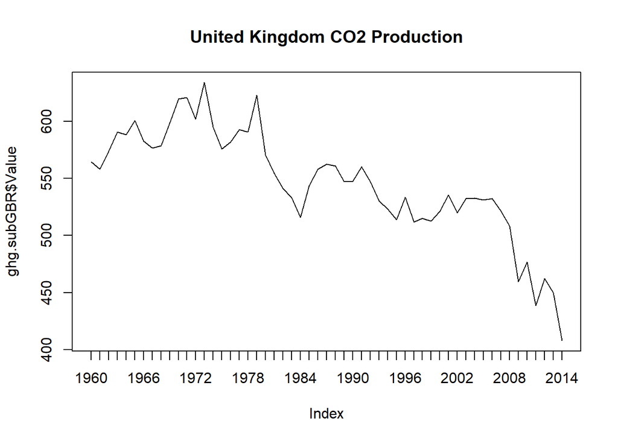

```r
ghg.subGBR <-ghg.sub2[ghg.sub2$COUNTRY == 'GBR', ]
plot(ghg.subGBR$Value,  main="United Kingdom CO2 Production", type = "l",  xaxt = "n")
axis(1, at=1:55, labels=ghg.subGBR$TIME)
```

### World subset and graph:

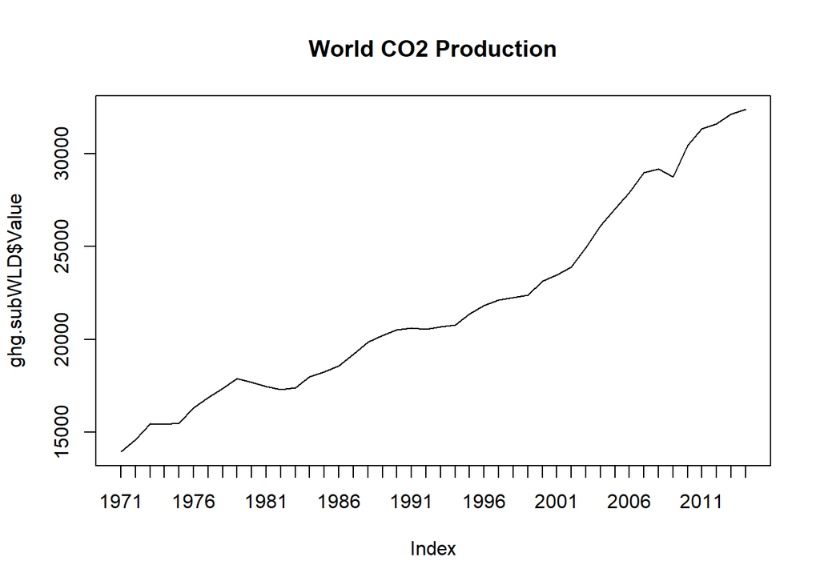

```r
ghg.subWLD <- ghg.sub2[ghg.sub2$COUNTRY == 'WLD',]
plot(ghg.subWLD$Value, main="World CO2 Production", type = "l", xaxt = "n")
axis(1, at=1:44, labels=ghg.subWLD$TIME)
```

### OED subset and graph:

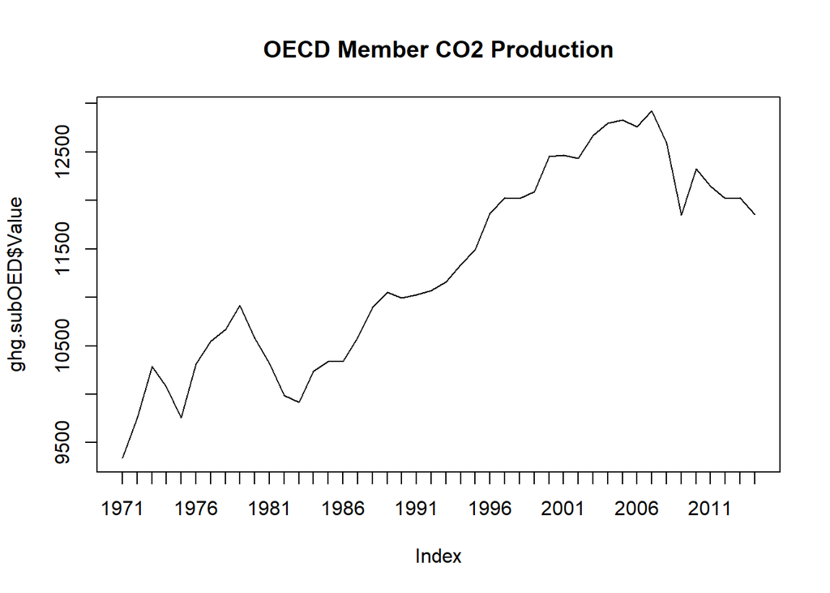

```r
ghg.subOED <- ghg.sub2[ghg.sub2$COUNTRY == 'OED',]
plot(ghg.subOED$Value,  main="OECD Member CO2 Production", type = "l", xaxt = "n")
axis(1, at=1:44, labels=ghg.subOED$TIME)
```

# Q2:

## Are urbanization rates correlated to carbon dioxide emissions?

### create a dataset for question 2

```r
ghg1<- ghg
```

### converting Subject into factors

```r
ghg1$SUBJECT <- factor(ghg1$SUBJECT)
```

### converting Region into factors

```r
ghg1$Region <- factor(ghg1$Region)
```

### converting measure into factors

```r
ghg1$MEASURE <- factor(ghg1$MEASURE)
```

### View a summary of data

```r
summary(ghg1)
```

```
##     COUNTRY            INDICATOR     SUBJECT              MEASURE
##  AUS    :  362   AIREMISSION:20726   CO : 1764   KG_CAP       :3527
##  AUT    :  362                       CO2:11650   MLN_TONNE    :5825
##  BEL    :  362                       GHG: 2022   THND_TONNE   :3527
##  CAN    :  362                       NOX: 1764   THND_TONNECO2:1011
##  CHE    :  362                       SOX: 1764   TONNE_CAP    :6836
##  DEU    :  362                       VOC: 1762
##  (Other):18554
##  FREQUENCY      TIME          Value          Flag.Codes
##  A:20726   Min.   :1960   Min.   :       0    :20696
##            1st Qu.:1990   1st Qu.:       5   B:   30
##            Median :1998   Median :      20
##            Mean   :1997   Mean   :   45565
##            3rd Qu.:2007   3rd Qu.:     126
##            Max.   :2015   Max.   :16844806
##
##  Lookup.Column.Index Urbanization.       Population
##  Min.   : 4.00       Min.   :  4.005   Min.   :1.194e+05
##  1st Qu.:34.00       1st Qu.: 53.360   1st Qu.:4.491e+06
##  Median :42.00       Median : 68.862   Median :1.030e+07
##  Mean   :40.62       Mean   : 65.030   Mean   :7.998e+07
##  3rd Qu.:51.00       3rd Qu.: 79.583   3rd Qu.:4.000e+07
##  Max.   :59.00       Max.   :100.000   Max.   :7.269e+09
##
##              Region        OECD_Flag
##  Europe         :10022   Min.   :0.000
##  Africa         : 2308   1st Qu.:0.000
##  Western Asia   : 2124   Median :0.000
##  Southern Asia  : 1200   Mean   :0.492
##  Central America: 1130   3rd Qu.:1.000
##  South America  : 1054   Max.   :1.000
##  (Other)        : 2888
```

### creating a subset for CO2

```r
ghg1.sub <- ghg1[ghg1$SUBJECT == 'CO2', ]
```

### creating a subset for CO2 measured in Millions of Tons

```r
ghg1.sub2 <- ghg.sub[ghg.sub$MEASURE == 'MLN_TONNE', ]
```

### creating a subset for CO2 for time 2000-2014

```r
ghg1.sub3 <- ghg.sub2[ghg.sub2$TIME>2000 & ghg.sub2$TIME<2015, ]
```

### Scatterplot between time and value

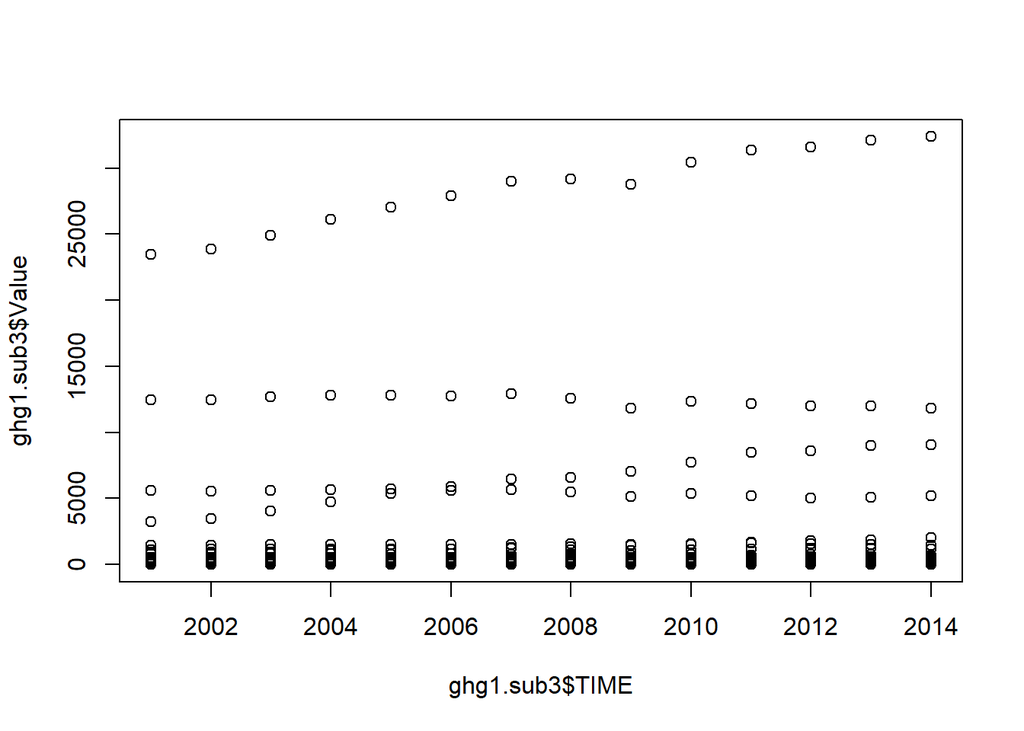

```r
plot(ghg1.sub3$Value~ghg1.sub3$TIME)
```

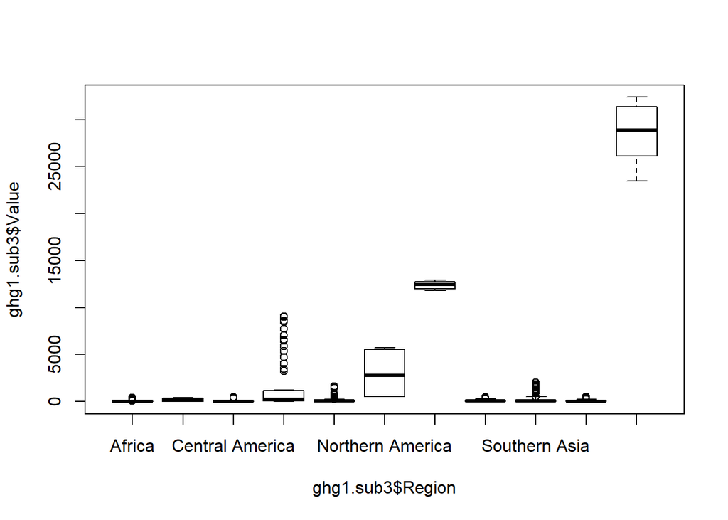

```r
plot(ghg1.sub3$Value~ghg1.sub3$Region)
```

### creating a subset of CO2 values for year 2012.

```r
ghg1.sub2012<-ghg1.sub3[ghg1.sub3$TIME==2012,]
```

```r
top52012 <- head(ghg1.sub2012[order(ghg1.sub2012$Urbanization., decreasing= T),], n = 15,)
```

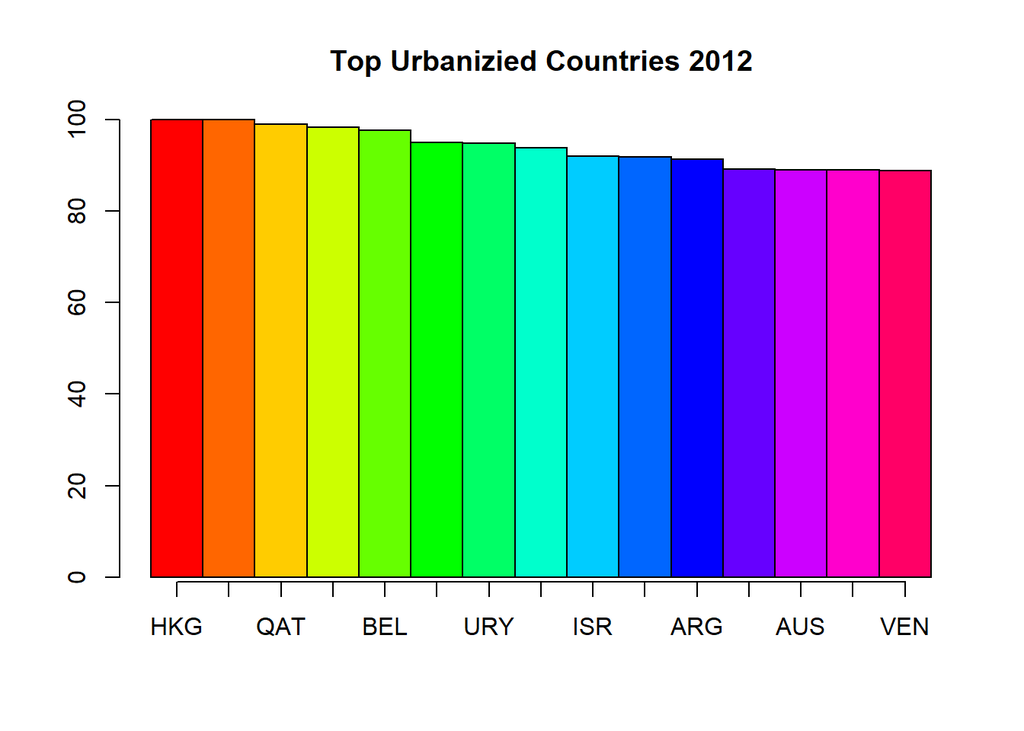

```r
barplot(top52012$Urbanization., main="Top Urbanizied Countries 2012", col = rainbow(15), space=0)
axis(1, at= .5:14.5, labels=top52012$COUNTRY)
```

# Q3:

## Are Nitrogen Oxides (NOX) and Sulphur Oxides (SOX) emissions highest from OECD (Organization for Economic Cooperation and Development) member countries? Are these emissions correlated to urbanization?

### Get the sunset of rows that are having the subject as NOX

```r
nox.sub <- ghg[ghg$SUBJECT == 'NOX', ]
```

### Get the sunset of rows that are having the subject as SOX

```r
nox.sub1 <- ghg[ghg$SUBJECT == 'SOX', ]
```

### Vertical merging of rows that are having the subject as NOX and SOX

```r
nox_sox<-rbind(nox.sub,nox.sub1)
```

### Subset the values that are having the measure as ‘THND_TONNE’

```r
nox_sox_ton <- nox_sox[nox_sox$MEASURE == 'THND_TONNE', ]
```

### Remove the unnecessary columns

```r
nox_sox_req<-nox_sox_ton[,c(1,3,6,7)]
```

### Aggregate or Sum the values for each country over the years. This gives the sum of values of emmission of NOX or SOX gases for the country.

```r
nox_sox_grouped<-aggregate(nox_sox_req$Value, by=list(Country=nox_sox_req$COUNTRY), FUN=sum)
```

### This gives the country that has the maximum nox_Sox emmission

```r
nox_sox_grouped[which.max(nox_sox_grouped$x),]
```

```
##    Country       x
## 30     OED 1773509
```

# R Script for Final Plots:

#### Load data:

```r
ghg <- read.csv("https://raw.githubusercontent.com/MBWitz/DataSurfers/master/air_ghg_data_w_regions_new1230.csv")
```

# Q1:

## Which countries and regions contribute the most CO2 emissions, both on a total volume basis and from a per capita perspective? Do the top offenders have similar patterns of increasing and decreasing emissions?

#### Create a subset of just CO2 values:

```r
ghg.sub <- ghg[ghg$SUBJECT == 'CO2', ]
```

#### Create a subset of CO2 set with CO2 that is measured in Millions of Tons:

```r
ghg.sub2 <- ghg.sub[ghg.sub$MEASURE == 'MLN_TONNE', ]
```

#### Create a subset with 7 countries who have been in top five since 1971 (checked ten dates at approximately 5 year intervals between 1971 and 2014 in last week’s R Script):

```r
top7data<- ghg.sub2[ghg.sub2$COUNTRY=="USA"|ghg.sub2$COUNTRY=="CHN"|ghg.sub2$COUNTRY=="DEU"|ghg.sub2$COUNTRY=="RUS"|ghg.sub2$COUNTRY=="IND"|ghg.sub2$COUNTRY=="GBR"|ghg.sub2$COUNTRY=="JPN",]
```

#### Include only CO2 measured since 1971 (because several countries have no data prior)

```r
top7CO2<- top7data[top7data$TIME>=1971, ]
summary(top7CO2)
```

```
##     COUNTRY         INDICATOR   SUBJECT            MEASURE    FREQUENCY
##  CHN    :44   AIREMISSION:289   CO :  0   KG_CAP       :  0   A:289
##  DEU    :44                     CO2:289   MLN_TONNE    :289
##  GBR    :44                     GHG:  0   THND_TONNE   :  0
##  IND    :44                     NOX:  0   THND_TONNECO2:  0
##  JPN    :44                     SOX:  0   TONNE_CAP    :  0
##  USA    :44                     VOC:  0
##  (Other):25
##       TIME          Value        Flag.Codes Lookup.Column.Index
##  Min.   :1971   Min.   : 181.0    :289      Min.   :15.00
##  1st Qu.:1983   1st Qu.: 740.6   B:  0      1st Qu.:27.00
##  Median :1994   Median :1046.0              Median :38.00
##  Mean   :1993   Mean   :1884.0              Mean   :37.32
##  3rd Qu.:2004   3rd Qu.:2019.7              3rd Qu.:48.00
##  Max.   :2014   Max.   :9087.0              Max.   :58.00
##
##  Urbanization.     Population                              Region
##  Min.   :17.18   Min.   :5.590e+07   Europe                   :113
##  1st Qu.:34.87   1st Qu.:8.168e+07   Eastern Asia             : 88
##  Median :73.60   Median :1.453e+08   Northern America         : 44
##  Mean   :62.14   Mean   :4.065e+08   Southern Asia            : 44
##  3rd Qu.:78.11   3rd Qu.:7.992e+08   Africa                   :  0
##  Max.   :93.02   Max.   :1.364e+09   Australia and New Zealand:  0
##                                      (Other)                  :  0
##    OECD_Flag      YearPopulation
##  Min.   :0.0000   Min.   :1.658e+09
##  1st Qu.:0.0000   1st Qu.:1.163e+10
##  Median :0.0000   Median :1.560e+10
##  Mean   :0.4567   Mean   :2.035e+10
##  3rd Qu.:1.0000   3rd Qu.:3.592e+10
##  Max.   :1.0000   Max.   :4.357e+10
##
```

#### Line plots of CO2 emissions in top 7 countries, different color for each country:

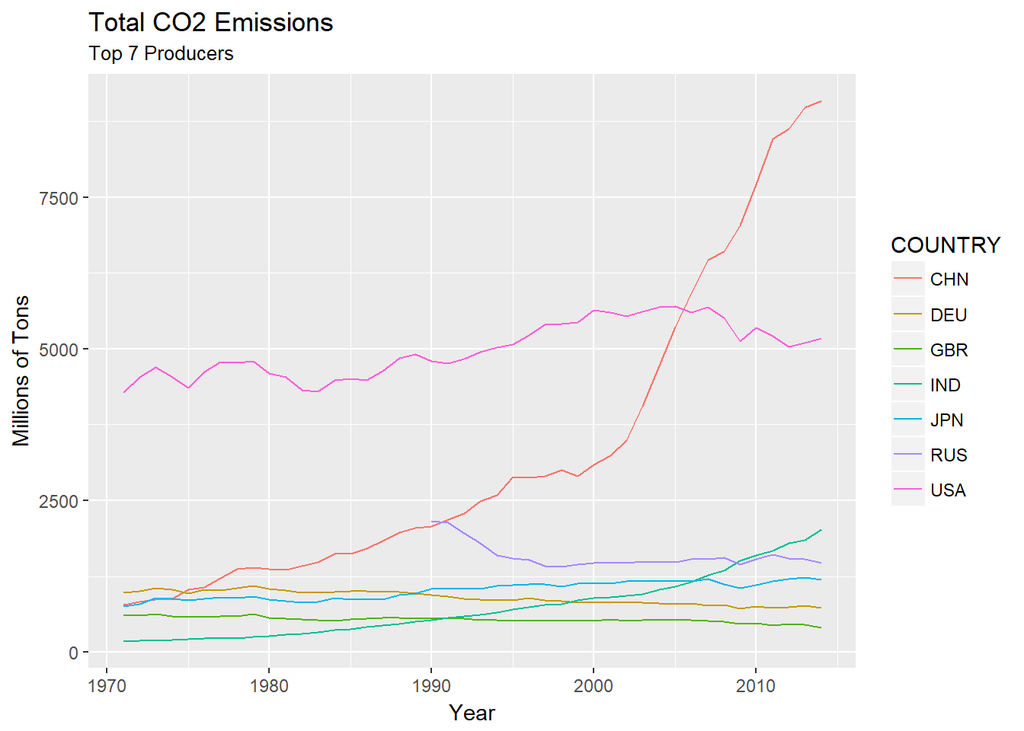

```r
require(ggplot2)
ggplot(data = top7CO2, aes(x = TIME, y = Value, group = COUNTRY)) + xlab("Year") + ylab("Millions of Tons") + ggtitle("Total CO2 Emissions", subtitle="Top 7 Producers") + geom_line(aes(color = COUNTRY))
```

#### Calculate per capita CO2 emissions for top7 and plot them:

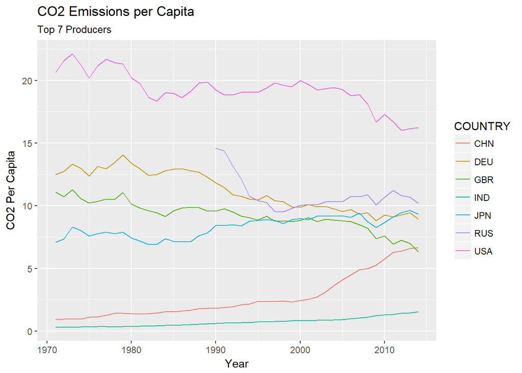

```r
top7CO2$CO2percap <- with(top7CO2, (top7CO2$Value/top7CO2$Population)*1000000)
ggplot(data = top7CO2, aes(x = TIME, y = CO2percap, group = COUNTRY)) +
     xlab("Year") + ylab("CO2 Per Capita") +
     ggtitle("CO2 Emissions per Capita", subtitle="Top 7 Producers") +
     geom_line(aes(color = COUNTRY))
```

When considering per capita CO2 emissions, the USA is consistently significantly higher than any other country of the top 7 CO2 emissions producing countries. The USA, Germany, and Great Britain exhibit decreasing trend over time, while Japan and India are growing slowly, and China grew quite rapidly in the last two decades. Russia has not exhibited a consistent pattern, but their CO2 emissions per capita are consistently among the highest.

#### Summarize CO2 Emissions by Region, eliminating OECD member nation data and World Data:

```r
ghg.sub3<-ghg.sub2[ghg.sub2$COUNTRY!="WLD"&ghg.sub2$COUNTRY!="OED",]
ghg.region<- with(ghg.sub3,(aggregate(list(Population=ghg.sub3$Population,Value=ghg.sub3$Value), by=list(Region=ghg.sub3$Region, TIME=ghg.sub3$TIME), FUN=sum)))
```

#### Calculate per capita emissions by region:

```r
ghg.region$CO2percap <- with(ghg.region, (ghg.region$Value/ghg.region$Population)*1000000)
```

#### Graph CO2 emissions by region and per Capita by region starting in 1971:

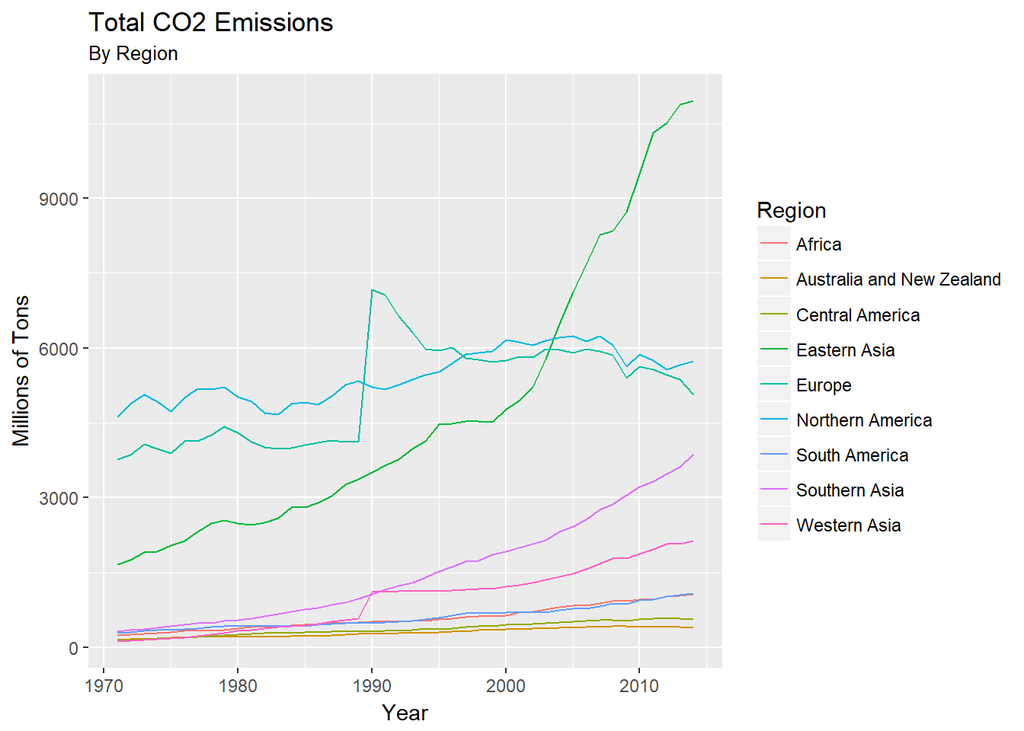

```r
ghg.region<-ghg.region[ghg.region$TIME>=1971,]
ggplot(data = ghg.region, aes(x = TIME, y = Value, group = Region)) +
     xlab("Year") + ylab("Millions of Tons") +
     ggtitle("Total CO2 Emissions", subtitle="By Region") +
     geom_line(aes(color = Region))
```

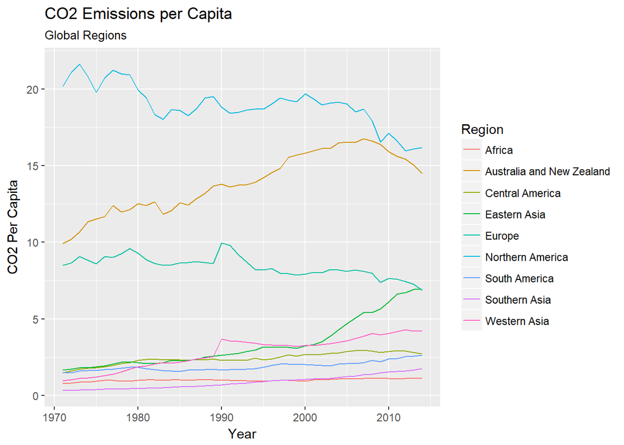

```r
ggplot(data = ghg.region, aes(x = TIME, y = CO2percap, group = Region)) +
     xlab("Year") + ylab("CO2 Per Capita") +
     ggtitle("CO2 Emissions per Capita", subtitle="Global Regions") +
     geom_line(aes(color = Region))
```

# Q2

## Are urbanization rates correlated to carbon dioxide emissions?

#### Create a subset by removing WLD ans OED countries.

```r
ghg.sub3<-subset(ghg.sub2, ghg.sub2$COUNTRY!='WLD' & ghg.sub2$COUNTRY!='OED')
```

#### Summary of the subset.

```r
summary(ghg.sub3)
```

```
##     COUNTRY           INDICATOR    SUBJECT             MEASURE
##  AUS    :  55   AIREMISSION:5737   CO :   0   KG_CAP       :   0
##  AUT    :  55                      CO2:5737   MLN_TONNE    :5737
##  BEL    :  55                      GHG:   0   THND_TONNE   :   0
##  CAN    :  55                      NOX:   0   THND_TONNECO2:   0
##  CHE    :  55                      SOX:   0   TONNE_CAP    :   0
##  DEU    :  55                      VOC:   0
##  (Other):5407
##  FREQUENCY      TIME          Value         Flag.Codes Lookup.Column.Index
##  A:5737    Min.   :1960   Min.   :   0.19    :5737     Min.   : 4.00
##            1st Qu.:1981   1st Qu.:   5.07   B:   0     1st Qu.:25.00
##            Median :1993   Median :  22.84              Median :37.00
##            Mean   :1992   Mean   : 163.92              Mean   :36.24
##            3rd Qu.:2004   3rd Qu.:  86.83              3rd Qu.:48.00
##            Max.   :2014   Max.   :9086.96              Max.   :58.00
##
##  Urbanization.       Population                    Region
##  Min.   :  4.005   Min.   :1.194e+05   Europe         :1673
##  1st Qu.: 39.969   1st Qu.:4.111e+06   Africa         :1152
##  Median : 58.965   Median :1.003e+07   Western Asia   : 871
##  Mean   : 57.308   Mean   :4.104e+07   Southern Asia  : 592
##  3rd Qu.: 75.015   3rd Qu.:3.078e+07   Central America: 528
##  Max.   :100.000   Max.   :1.364e+09   South America  : 440
##                                        (Other)        : 481
##    OECD_Flag      YearPopulation
##  Min.   :0.0000   Min.   :1.048e+08
##  1st Qu.:0.0000   1st Qu.:1.276e+10
##  Median :0.0000   Median :1.928e+10
##  Mean   :0.2695   Mean   :2.429e+10
##  3rd Qu.:1.0000   3rd Qu.:3.839e+10
##  Max.   :1.0000   Max.   :4.357e+10
##
```

#### Create a basic scatter plot between Value and Urbanization to understand how they are correlated.

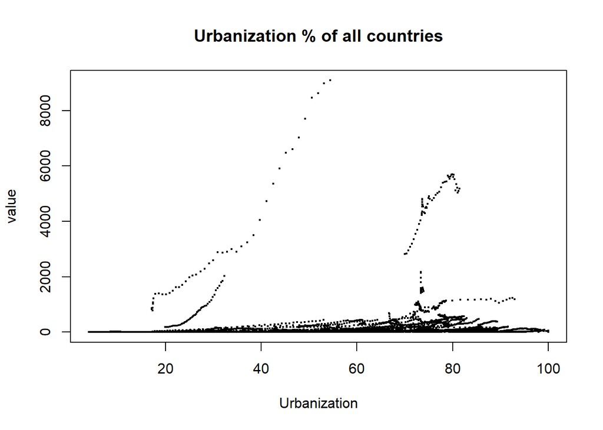

```r
x= ghg.sub3$Urbanization.
y= ghg.sub3$Value
 plot(x,y,main="Urbanization % of all countries",cex=.25, xlab="Urbanization", ylab="value")
```

This plot seems to show an overall positive correlation between urbanization and CO2 emissions, but most of the data is very condensed at the bottom of the graph due to outliers. We will eliminate the outliers so that the remainder of the data can be more spread out.

#### Create another subset by eliminating USA and China.

```r
ghg.sub4<-subset(ghg.sub3, ghg.sub3$COUNTRY!='USA' & ghg.sub3$COUNTRY!='CHN')
```

#### Create a scatter plot between value and urbanization with the new subset that we have created.

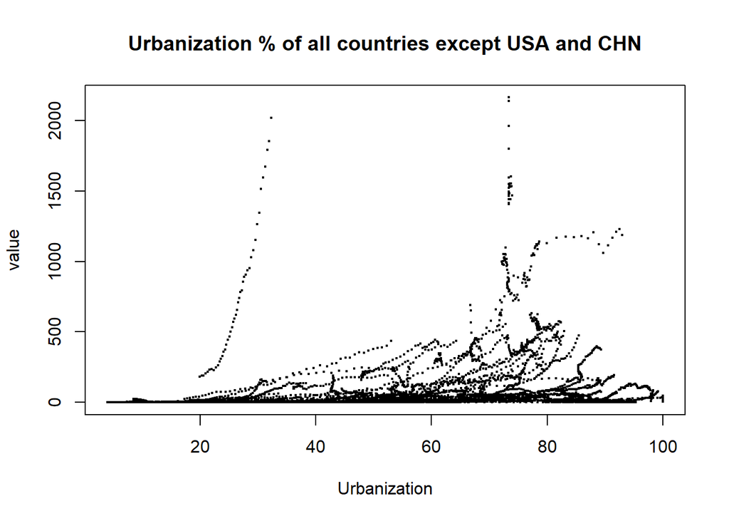

```r
x=ghg.sub4$Value
y=ghg.sub4$Urbanization.
plot(y,x,main="Urbanization % of all countries except USA and CHN",cex=.25, xlab="Urbanization",ylab="value")
```

This plot confirms the positive correlation overall between urbanization and CO2 emissions.

#### A best fit line enables us to see the positive correlation better.

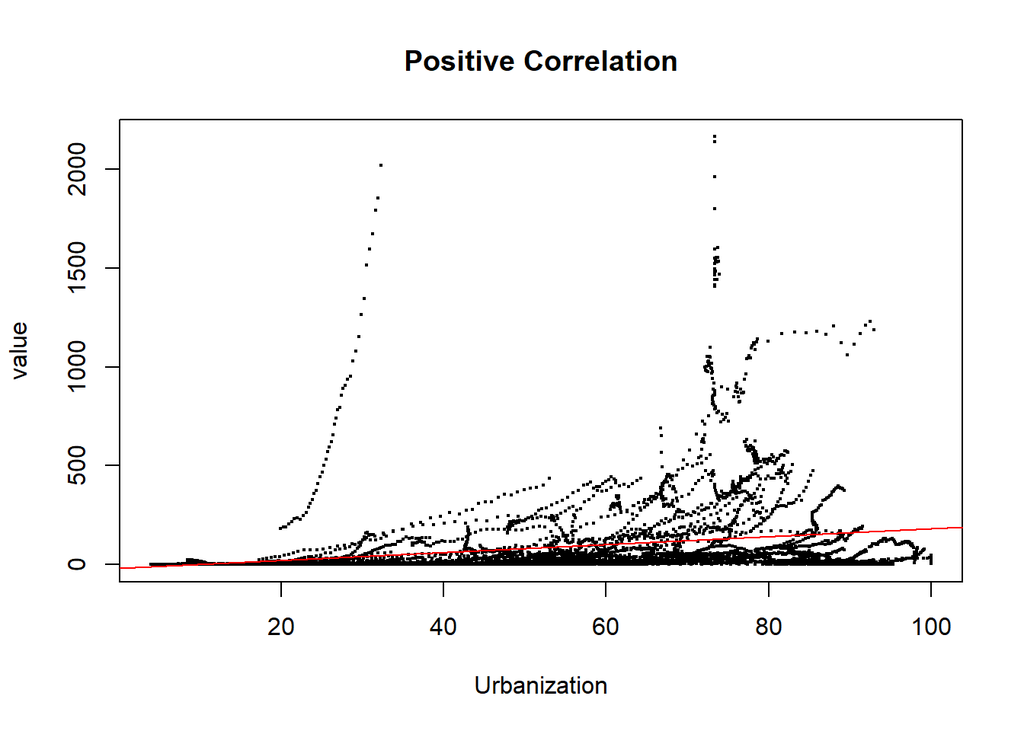

```r
y = ghg.sub4$Value
x =ghg.sub4$Urbanization.
plot(x,y,main="Positive Correlation", cex=.25, xlab="Urbanization",ylab="value")
abline(lm(y~x), col="red")
```

We have not distinguished countries in these plots as we are looking for overall trend. The next set of plots shows how individual countries reflect increasing emissions with increasing urbanization rates.

#### Find the correlation value to confirm that it is positive.

```r
cor(ghg.sub4$Value, ghg.sub4$Urbanization) # =.22
```

```
## [1] 0.2208416
```

```r
require(ggplot2)
```

#### Graph CO2 and Urbanization percentage by country, showing different countries in different colors.

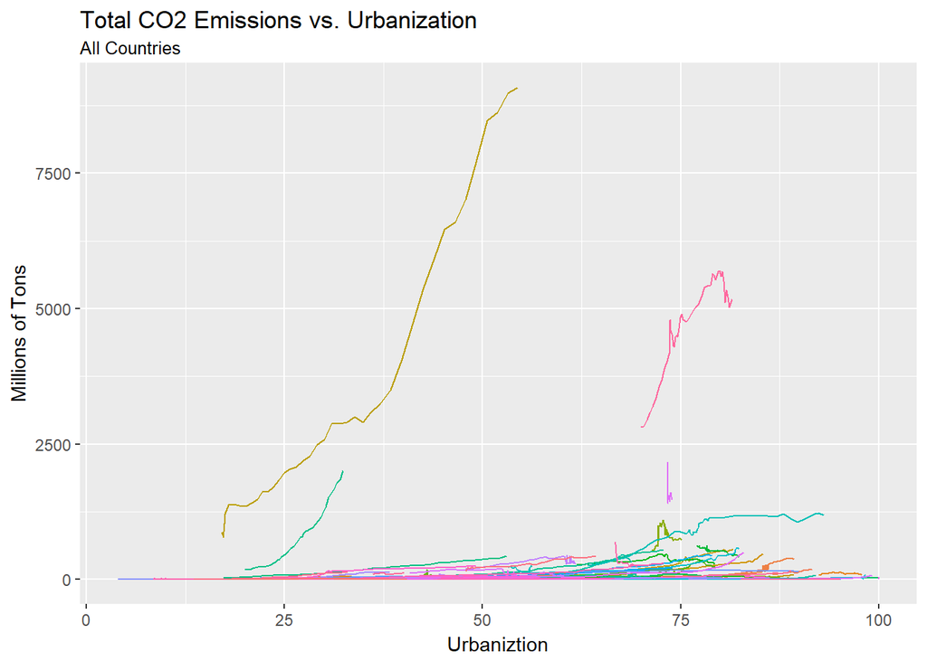

```r
ggplot(data = ghg.sub3, aes(x = Urbanization., y = Value, group = COUNTRY)) +
xlab("Urbaniztion") + ylab("Millions of Tons") + theme(legend.position="none") +
ggtitle("Total CO2 Emissions vs. Urbanization", subtitle="All Countries") +
 geom_line(aes(color = COUNTRY))
```

This plot shows the correlation between Urbanization percentage and CO2 gas emmision with respect to each country including CHINA and USA. The legend was eliminated because there are so many countries, the graph gets too compressed when the legend is displayed.

#### Create subset for countries having CO2 Emissions greater than 500 million tonnes

```r
ghg.sub5<-ghg.sub3[ghg.sub3$Value>=500, ]
```

#### Graph CO2 and Urbanization percentage with new subset.

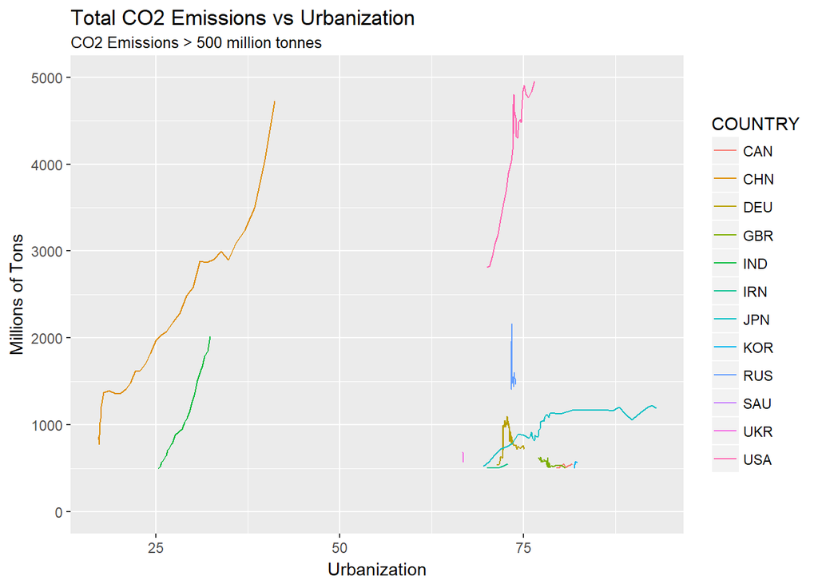

```r
ggplot(data = ghg.sub5, aes(x = Urbanization., y = Value, group = COUNTRY))+
xlab("Urbanization") + ylab("Millions of Tons") + theme(legend.position='right')+ ylim(0,5000)+
ggtitle("Total CO2 Emissions vs Urbanization", subtitle="CO2 Emissions > 500 million tonnes")+ geom_line(aes(color = COUNTRY))
```

This plot shows the correlation between Urbanization percentage and CO2 emmisions where CO2 emissions are greater than 500 million tons. This plot makes it easier to visualize the positive correlation between Urbanization and CO2 emissions.

#### Create subset of countries with population greater than 100 million

```r
ghg.sub6<-ghg.sub3[ghg.sub3$Population>100000000, ]
```

#### Plot Graph for the new subset having population greater than 100 million

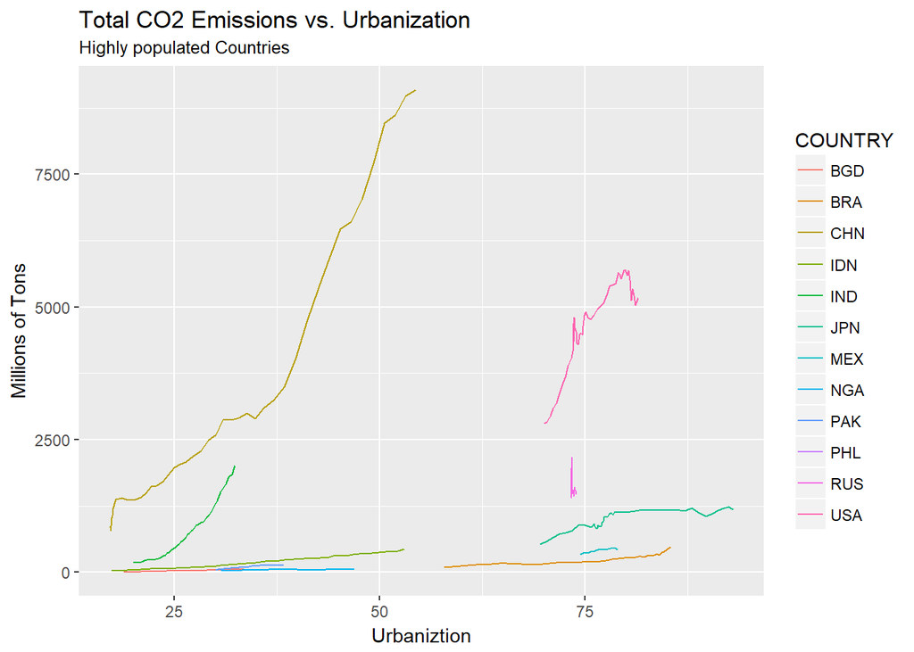

```r
ggplot(data = ghg.sub6, aes(x = Urbanization., y = Value, group = COUNTRY)) +
xlab("Urbaniztion") + ylab("Millions of Tons") + theme(legend.position="right") +
ggtitle("Total CO2 Emissions vs. Urbanization", subtitle="Highly populated Countries") +
 geom_line(aes(color = COUNTRY))
```

```r
ghg.sub7<-ghg.sub3[ghg.sub3$Population<1000000, ]
```

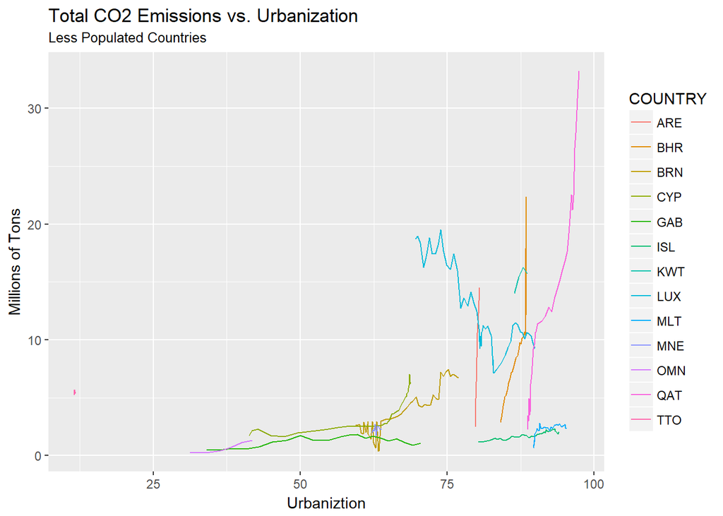

```r
ggplot(data = ghg.sub7, aes(x = Urbanization., y = Value, group = COUNTRY)) +
xlab("Urbaniztion") + ylab("Millions of Tons") + theme(legend.position="right") +
ggtitle("Total CO2 Emissions vs. Urbanization ", subtitle="Less Populated Countries") +
 geom_line(aes(color = COUNTRY))
```

This plot shows that less populated countries are mostly urbanized( 12 out of 13). Luxembourg country has a sudden decrease in CO2 emissions. Out of 13 countries, 3 countries show increase in their CO2 emissions with Urbanization almost remaining constant.

# Q3:

## Are Nitrogen Oxides (NOX) and Sulphur Oxides (SOX) emissions highest from OECD (Organization for Economic Cooperation and Development) member countries? Are these emissions correlated to urbanization?

#### Create a subset of just Nitrogen Oxide Emissions data:

```r
nox.sub <- ghg[ghg$SUBJECT == 'NOX', ]
```

#### Create a subset of just Sulphur Oxide emissions data:

```r
nox.sub1 <- ghg[ghg$SUBJECT == 'SOX', ]
```

#### Vertical merging of rows that are having the subject as NOX and SOX

```r
nox_sox<-rbind(nox.sub,nox.sub1)
```

#### Subset the values that are having the measure as ‘THND_TONNE’

```r
nox_sox_tonn <- nox_sox[nox_sox$MEASURE == 'THND_TONNE', ]
```

#### Remove the unnecessary columns

```r
 nox_sox_req<-nox_sox_tonn[,c(1,3,6,7,10,11,13,14)]
```

##### Calcuate the urbanized population from percentage and total population

```r
nox_sox_req$urbanized<-with(nox_sox_req, (nox_sox_req$Urbanization*nox_sox_req$Population)/100)
```

##### Aggregate or Sum the values for all countries over the years. This gives the sum of values of emmission of NOX or SOX gases for the country.

```r
nox_sox_grouped_value<-aggregate(nox_sox_req$Value, by=list(TIME=nox_sox_req$TIME,OECD_Flag=nox_sox_req$OECD_Flag), FUN=sum)
```

###### Column name for x is chnaged to value

```r
colnames(nox_sox_grouped_value)[3] <- "VALUE";
```

###### Aggregate or Sum the urbanzed poplation for all countries over the years. This gives the percentages of urbanized people in all countries in the year.

```r
nox_sox_grouped_urban<-aggregate(((nox_sox_req$urbanized/nox_sox_req$YearPopulation)*100), by=list(TIME=nox_sox_req$TIME,OECD_Flag=nox_sox_req$OECD_Flag), FUN=sum)
```

###### Column name for x is chnaged to URBAN

```r
colnames(nox_sox_grouped_urban)[3] <- "URBAN";
```

###### Dataframes nox_sox_grouped_urban and nox_sox_grouped_value are merged into m4

```r
m4<-merge(nox_sox_grouped_value,nox_sox_grouped_urban)
```

###### Seperating data for non OECD countries

```r
nox_sox_non_OECD = subset(m4,OECD_Flag == "0")
```

###### Seperating data for OECD countries

```r
nox_sox_OECD = subset(m4,OECD_Flag == "1")
```

###### Aggregate or Sum the values for each country over the years. This gives the sum of values of emmission of NOX or SOX gases for the country.

```r
nox_sox_grouped<-aggregate(nox_sox_req$Value, by=list(TIME=nox_sox_req$TIME,OECD_Flag=nox_sox_req$OECD_Flag), FUN=sum)
```

###### This shows the plot that show variation between OECD and NON-OECD Countries

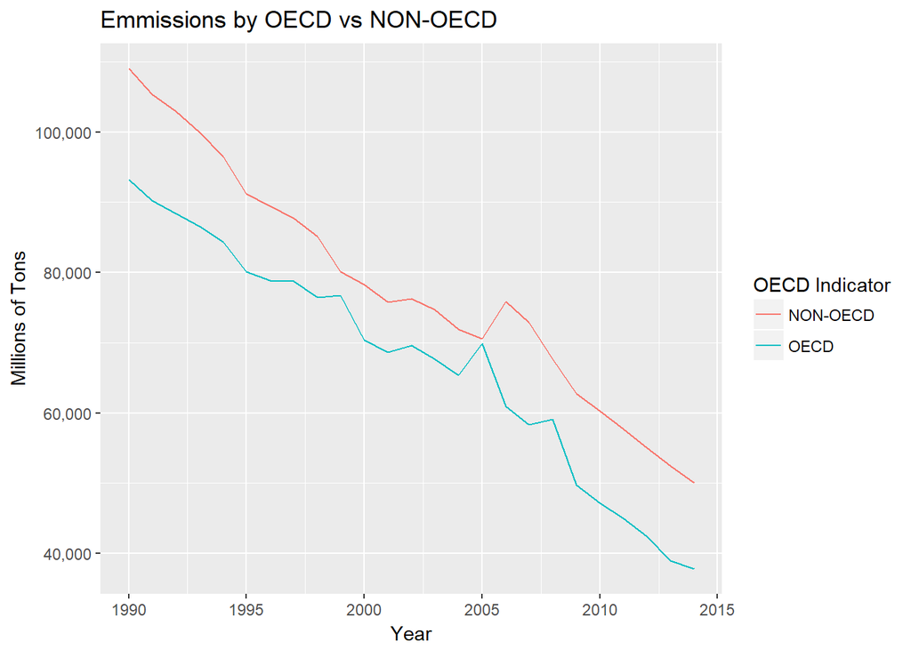

```r
ggplot(data = nox_sox_grouped, aes(x = TIME, y = x, group = factor(OECD_Flag))) +
  xlab("Year") + ylab("Millions of Tons") +
  geom_line(aes(color = factor(OECD_Flag)))+
  scale_color_discrete(name = "OECD Indicator", labels = c("NON-OECD", "OECD"))+
  ggtitle("Emmissions by OECD vs NON-OECD")+
  scale_y_continuous(labels=scales::comma)
```

The plot shows the emmissions of nox and sox gases made by OECD countries to that of non OECD countries from 1990 to 2014. Resultant plot shows decreasing emissions for both Nitrogen Oxide and Sulphur Oxide emissions, with OECD member countries NOX and SOX emissions lower than non-OECD member nations. The main reason for this is that China is in the non-OECD group.

###### This gives the plot that show relation between OECD countries and urbanization rate.

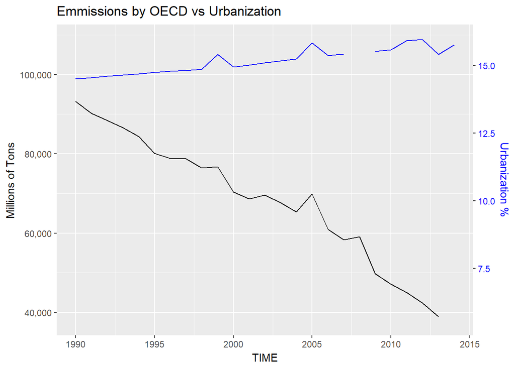

```r
ggplot(data=(nox_sox_OECD))+
  geom_line(color="black", mapping= aes(x= TIME , y= VALUE), stat="identity")+
  ylab("Millions of Tons")+
  geom_line(color="blue", mapping= aes(x= TIME , y= URBAN*(109052/13)), stat="identity")+
  theme(axis.title.y.right = element_text(color = "blue"),axis.text.y.right = element_text(color = "blue"))+
  scale_y_continuous(labels=scales::comma,name = expression("Millions of Tons"), sec.axis = sec_axis(~ . * 16/109052 ,name = "Urbanization %"),limits = c(37774,109052))+
  ggtitle("Emmissions by OECD vs Urbanization")
```

The plot shows the emmissions of nox and sox gases made by OECD countries to that of Urbanization percentage from 1990 to 2014. Resultant plot shows there are two scales or y axes for displaying the relation between OED countries emmision and their urbanization rate. As the percentage value is very less, I have tried to multiply the scale by 109052/13 where the numerator and denominator are the maximum values of nox,sox emmission and urbanization rate. It looks like some values are missing. They are not actually missiing but they did not fit the scale given. I did not try change the scale as there should be same gradient scale between OECD vs Urbanization and non-OECS vs Urbanization. The urbanization of OECD countries is high in the initial stages and has a gradual increase but did not have a sudden increase. However, plot shows that the emmissions started decreasing with increasing urbanization rate.

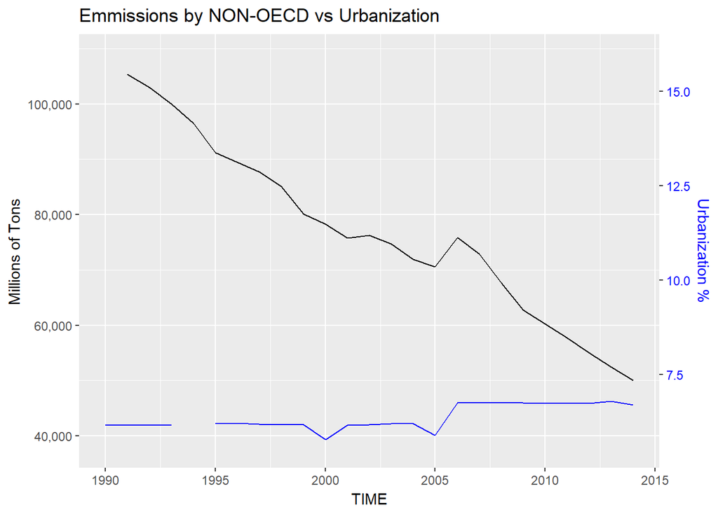

```r
ggplot(data=(nox_sox_non_OECD))+
  geom_line(color="black", mapping= aes(x= TIME , y= VALUE), stat="identity")+
  ylab("Millions of Tons")+
  geom_line(color="blue", mapping= aes(x= TIME , y= URBAN*(109052/13)), stat="identity")+
  theme(axis.title.y.right = element_text(color = "blue"),axis.text.y.right = element_text(color = "blue"))+
  scale_y_continuous(labels=scales::comma,name = expression("Millions of Tons"), sec.axis = sec_axis(~ . * 16/109052 ,name = "Urbanization %"),limits = c(37774,109052))+
  ggtitle("Emmissions by NON-OECD vs Urbanization")
```